# R Notebook

### Upstairs SF Area

**X1stFlrSF:** First Floor square feet.

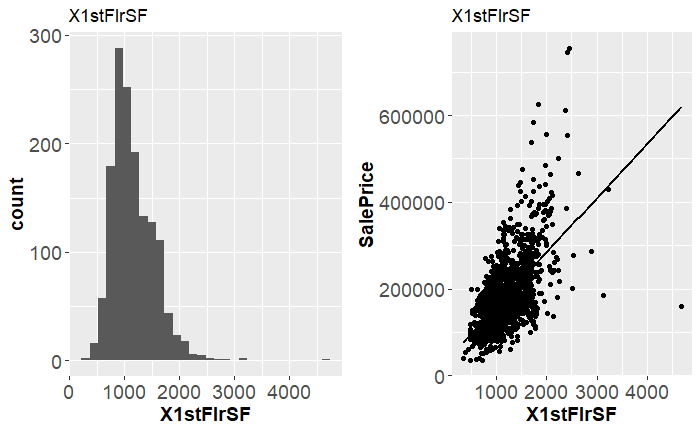

```r
numericggplot("X1stFlrSF")
```

**X2ndFlrSF:** Second floor square feet.

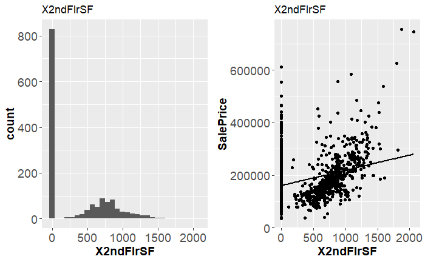

```r
numericggplot("X2ndFlrSF")
```

**LowQualFinSF:** Low quality finished square feet (all floors). Only twenty-six houses in the train data set have low quality finished square feet.

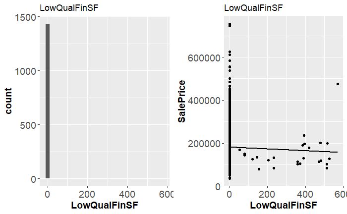

```r
numericggplot("LowQualFinSF")
```

```r
train %>% filter(LowQualFinSF>0) %>% count()
```

| n |
| --- |
| 26 |

**GrLivArea:** Above grade (ground) living area square feet.

First floor square feet + second floor square feet + low quality square feet = above ground living area for each observation. Observation 1299 comes up again as an outlier, will likely be dropped in feature engineering stage.

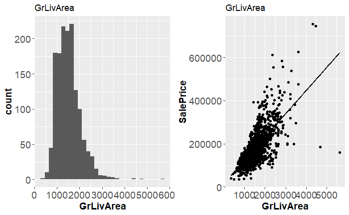

```r
numericggplot("GrLivArea")
```

```r
sum(train$X1stFlrSF+train$X2ndFlrSF+train$LowQualFinSF!=train$GrLivArea)/nrow(train)
```

```
[1] 0
```

```r
kable(train[train$GrLivArea>5000,c("Id","SalePrice","GrLivArea","LowQualFinSF","X2ndFlrSF","X1stFlrSF")])
```

|  | Id | SalePrice | GrLivArea | LowQualFinSF | X2ndFlrSF | X1stFlrSF |
| --- | --- | --- | --- | --- | --- | --- |
| 1299 | 1299 | 160000 | 5642 | 0 | 950 | 4692 |

$\textbf{Pick the next tab in order to see other variables.}$

### Number of Bathrooms

**BsmtFullBath:** Basement full bathrooms. Only one house has three full bathrooms in the basement. Although it appears unlikely for a basement of that size to have three full bathrooms, it is not entirely impossible. We can analyze this from the box-plot where a basement of a similar size has two full basement bathrooms.

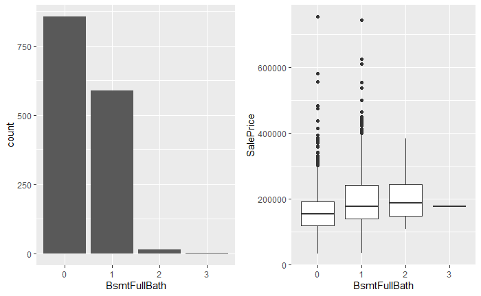

```r
discreteggplot("BsmtFullBath")
```

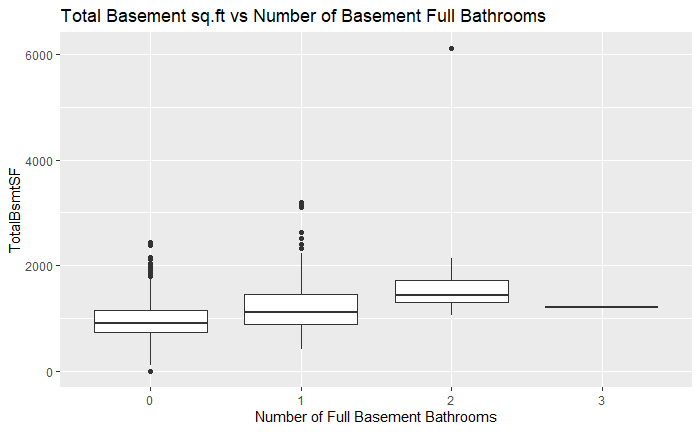

```r
ggplot(train,aes(x=as.factor(BsmtFullBath),y=TotalBsmtSF))+
  geom_boxplot()+
  xlab("Number of Full Basement Bathrooms")+
  labs(title="Total Basement sq.ft vs Number of Basement Full Bathrooms")
```

**BsmtHalfBath:** Basement half bathrooms.

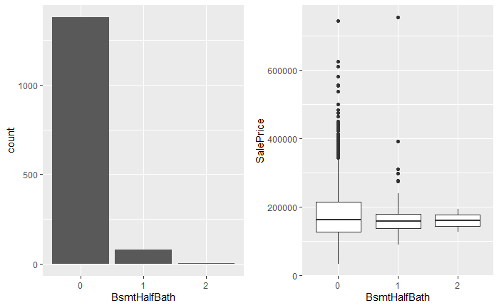

```r
discreteggplot("BsmtHalfBath")
```

**FullBath:** Full bathrooms above grade.

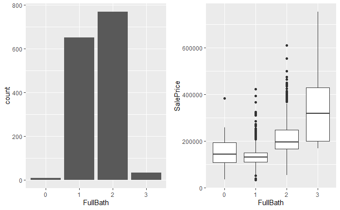

```r
discreteggplot("FullBath")
```

**HalfBath:** Half baths above grade.

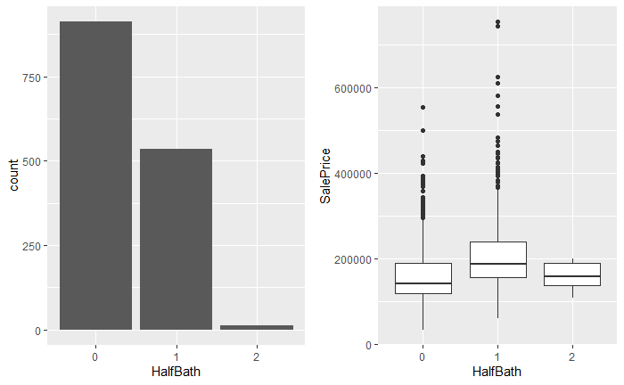

```r
discreteggplot("HalfBath")
```

There is no variable for the total bathrooms in a house. This will be added later on in the feature engineering section.

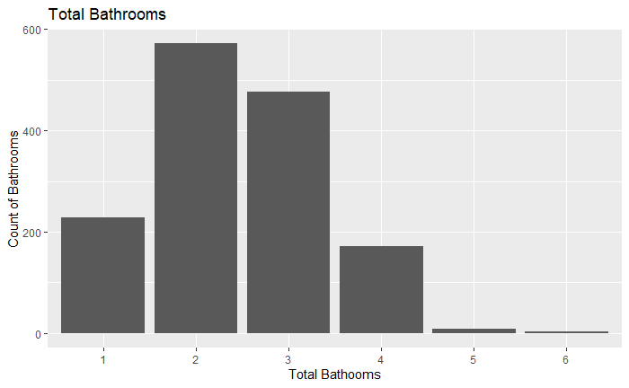

```r
train %>%
  mutate(totalBathrooms=BsmtFullBath+BsmtHalfBath+HalfBath+FullBath,na.rm=TRUE) %>%
  ggplot(.,aes(x=as.factor(totalBathrooms)))+
  geom_bar()+
  xlab("Total Bathooms")+
  ylab("Count of Bathrooms")+
  labs(title="Total Bathrooms")
```

$\textbf{Pick the next tab in order to see other variables.}$